# Final Assignment

Raju Rishikesh Gollapally

2023-12-03

# Summary:

k means clustering.

Plotting the within-cluster sum of squares (WSS) for various values of k allows one to apply the “WSS Method” to estimate the ideal number of clusters (k). Next, using the ideal k value that was discovered using the “WSS Method,” the k-means method is implemented. The ideal k value is also found using the silhouette approach.

We reapply the k-means algorithm using the optimal k value that we found using the “Silhouette Method.”

fviz_cluster is used to view the clustering results.

Group analysis/ Clustering

Each cluster’s attribute median values are computed and shown. The distribution of fuel types and fuel groups inside the clusters is shown using bar graphs.

The structure of the dataset is shown by plotting. MinPts and eps are the parameters used for DBSCAN clustering. Plot() and fviz_cluster are used to visualize the findings.

The ideal value for the eps parameter may be found with the use of the kNN distance plot.

1.What is the best K?

#installing the required packages

```r
library("dplyr")
library("ISLR")
library("caret")
```

```r
library("class")
library("ggplot2")
library("tidyverse")
library("gmodels")
library("factoextra")
library("fpc")
library("cluster")
library("dbscan")
```

#Importing the dataset into R

```r
fule_reciptss <- read.csv("fuel_receipts1.csv")
```

## Exploring Dataset

```r
summary(fule_reciptss)
```

```
##        X             rowid         plant_id_eia    energy_source_code
##  Min.   :  1.0   Min.   :   1.0   Min.   :   3.0   Length:756
##  1st Qu.:189.8   1st Qu.: 221.8   1st Qu.: 527.0   Class :character
##  Median :378.5   Median : 450.5   Median : 728.0   Mode  :character
##  Mean   :378.5   Mean   : 465.7   Mean   : 808.7
##  3rd Qu.:567.2   3rd Qu.: 704.2   3rd Qu.:1252.0
##  Max.   :756.0   Max.   :1000.0   Max.   :1710.0
##  fuel_type_code_pudl fuel_group_code    supplier_name      fuel_received_units
##  Length:756          Length:756         Length:756         Min.   :      1
##  Class :character    Class :character   Class :character   1st Qu.:   1300
##  Mode  :character    Mode  :character   Mode  :character   Median :  12570
##                                                            Mean   :  89258
##                                                            3rd Qu.:  42025
##                                                            Max.   :4823176
##  fuel_mmbtu_per_unit sulfur_content_pct ash_content_pct  fuel_cost_per_mmbtu
##  Min.   : 0.857      Min.   :0.0000     Min.   : 0.000   Min.   : 0.343
##  1st Qu.: 1.028      1st Qu.:0.0000     1st Qu.: 0.000   1st Qu.: 1.947
##  Median :17.141      Median :0.3200     Median : 5.000   Median : 3.082
##  Mean   :13.349      Mean   :0.7314     Mean   : 4.995   Mean   : 5.786
##  3rd Qu.:23.870      3rd Qu.:0.9400     3rd Qu.: 9.600   3rd Qu.: 8.400
##  Max.   :29.400      Max.   :6.6100     Max.   :20.900   Max.   :29.514
```

```r
head(fule_reciptss)
```

|  | X | rowid | plant_id_eia | energy_source_code | fuel_type_code_pudl | fuel_group_code | supplier_name | fuel_received_units | fuel_mmbtu_per_unit | sulfur_content_pct | ash_content_pct | fuel_cost_per_mmbtu |
| --- | --- | --- | --- | --- | --- | --- | --- | --- | --- | --- | --- | --- |
| 1 | 1 | 1 | 3 | BIT | coal | coal | interocean coal | 259412 | 23.100 | 0.49 | 5.4 | 2.135 |
| 2 | 2 | 2 | 3 | BIT | coal | coal | interocean coal | 52241 | 22.800 | 0.48 | 5.7 | 2.115 |
| 3 | 3 | 3 | 3 | NG | gas | natural_gas | bay gas pipeline | 2783619 | 1.039 | 0.00 | 0.0 | 8.631 |
| 4 | 4 | 4 | 7 | BIT | coal | coal | alabama coal | 25397 | 24.610 | 1.69 | 14.7 | 2.776 |
| 5 | 5 | 5 | 7 | BIT | coal | coal | d & e mining | 764 | 24.446 | 0.84 | 15.5 | 3.381 |
| 6 | 6 | 6 | 7 | BIT | coal | coal | alabama coal | 603 | 24.577 | 1.54 | 14.6 | 2.199 |

```r
dim(fule_reciptss)
```

```
## [1] 756  12
```

##Clustering the dataset

```r
colMeans(is.na(fule_reciptss))
```

```
##                   X               rowid        plant_id_eia  energy_source_code
##                   0                   0                   0                   0
## fuel_type_code_pudl     fuel_group_code       supplier_name fuel_received_units
##                   0                   0                   0                   0
## fuel_mmbtu_per_unit  sulfur_content_pct     ash_content_pct fuel_cost_per_mmbtu
##                   0                   0                   0                   0
```

```r
fule_reciptsse_cluster <- fule_reciptss[,10:12]
fule_reciptss.norm <- scale(fule_reciptsse_cluster)
```

##K MEANS

#Finding the Optimal K

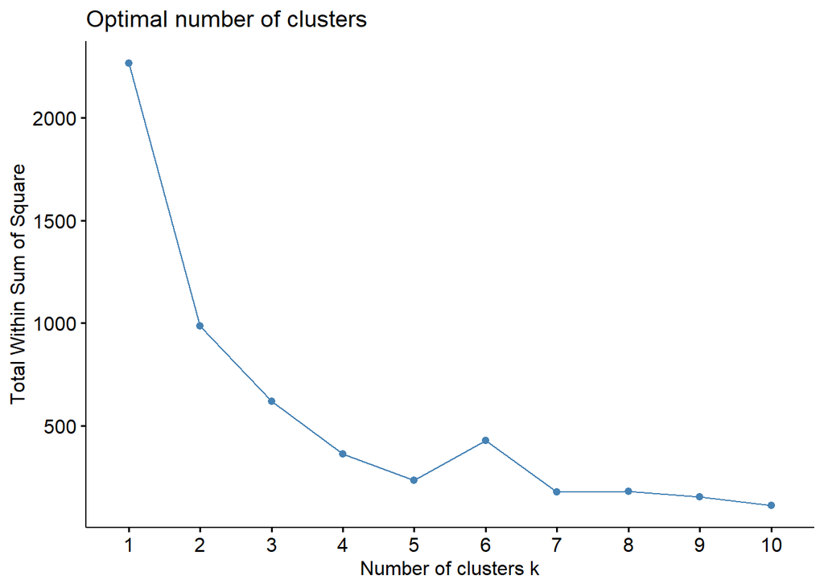

```r
fule_reciptss_WSS <- fviz_nbclust(fule_reciptss.norm,kmeans,method="wss")
fule_reciptss_WSS
```

```r
kmeans_wis <- kmeans(fule_reciptss.norm,centers = 2,nstart=20)
kmeans_wis
```

```
## K-means clustering with 2 clusters of sizes 422, 334
##
## Cluster means:
##   sulfur_content_pct ash_content_pct fuel_cost_per_mmbtu
## 1          0.5230871       0.7721576          -0.6845636
## 2         -0.6609064      -0.9756003           0.8649276
##
## Clustering vector:
##   [1] 1 1 2 1 1 1 2 1 1 1 1 1 1 2 2 1 1 1 1 1 1 2 1 1 1 1 1 1 1 1 1 1 1 1 1 1 1
##  [38] 1 1 2 2 1 1 1 1 1 1 1 1 1 1 1 1 1 1 2 2 2 2 2 1 1 2 2 1 1 1 1 1 1 1 2 2 2
##  [75] 1 2 2 2 2 2 2 2 2 2 2 2 2 2 2 2 2 2 2 2 2 1 1 1 1 2 1 1 1 2 2 2 2 2 2 2 1
## [112] 1 1 1 1 1 1 1 1 1 1 1 1 1 1 1 2 2 2 2 2 2 2 2 2 2 2 2 1 2 1 1 1 2 2 1 1 1
## [149] 2 2 2 1 1 2 2 2 2 2 2 2 2 2 2 2 2 1 1 1 2 1 1 1 1 2 2 1 1 1 1 2 1 2 1 1 2
## [186] 2 1 2 1 2 2 2 2 2 2 2 2 2 2 2 2 2 2 2 2 2 2 2 2 2 2 2 2 2 2 2 2 2 2 2 2 2
## [223] 2 2 2 2 2 2 2 2 2 2 2 2 2 2 2 2 2 2 2 2 2 2 2 2 2 2 2 2 2 2 2 2 2 2 2 2 2
## [260] 2 2 2 2 1 1 1 1 1 1 2 2 2 2 2 2 2 2 2 2 2 2 2 1 1 1 1 1 1 1 1 1 1 1 1 2 2
## [297] 2 2 1 1 2 1 1 1 1 2 1 1 2 2 2 1 2 2 2 2 2 1 2 1 1 1 1 2 2 2 2 2 2 2 2 1 1
## [334] 1 1 1 1 2 2 2 2 2 2 1 1 1 1 1 1 1 1 1 1 1 1 1 1 1 1 1 1 2 1 1 1 1 1 2 1 1
## [371] 1 1 1 2 1 1 1 1 1 1 1 1 1 1 2 2 2 2 1 1 2 1 2 2 2 1 1 1 1 1 1 1 1 1 2 2 1
## [408] 1 1 1 1 2 2 1 1 1 1 2 2 1 2 1 1 1 1 1 1 2 1 2 1 2 1 1 1 1 1 2 1 1 1 1 1 1
## [445] 2 2 1 2 2 2 2 2 2 1 2 1 1 1 1 1 1 1 1 1 1 1 1 2 1 1 2 1 2 2 1 2 2 2 1 1 2
## [482] 1 1 1 1 2 2 1 1 1 1 1 1 1 1 1 2 2 2 1 1 1 1 1 1 1 1 1 2 2 1 1 1 1 1 1 2 2
## [519] 1 1 1 1 2 1 2 1 1 2 2 2 1 1 2 1 1 1 2 2 2 2 2 2 2 1 1 2 2 1 1 2 2 1 1 1 1
## [556] 1 1 1 1 1 1 1 2 2 2 1 2 1 2 2 2 2 1 1 2 2 1 1 1 1 1 1 1 1 1 1 1 1 1 1 1 1
## [593] 1 1 1 1 1 1 1 1 1 1 1 1 1 1 1 1 2 1 1 1 1 1 2 2 2 1 1 1 1 1 1 1 1 1 1 1 1
## [630] 1 1 1 1 1 2 2 1 1 1 1 1 2 2 2 2 1 1 1 1 2 1 1 1 1 1 1 1 1 2 2 1 1 1 1 1 1
## [667] 1 1 1 2 1 1 1 1 1 1 1 2 2 2 1 1 1 1 1 1 1 1 1 2 2 1 1 1 2 2 2 1 2 2 2 2 1
## [704] 1 1 1 1 1 2 2 2 2 2 2 2 2 2 2 2 2 2 2 2 2 2 2 2 2 2 2 2 2 2 2 2 2 2 2 2 2
## [741] 2 2 1 1 1 1 1 1 1 1 1 1 1 1 1 1
##
## Within cluster sum of squares by cluster:
## [1] 680.1175 306.3908
##  (between_SS / total_SS =  56.4 %)
##
## Available components:
##
## [1] "cluster"      "centers"      "totss"        "withinss"     "tot.withinss"
## [6] "betweenss"    "size"         "iter"         "ifault"
```

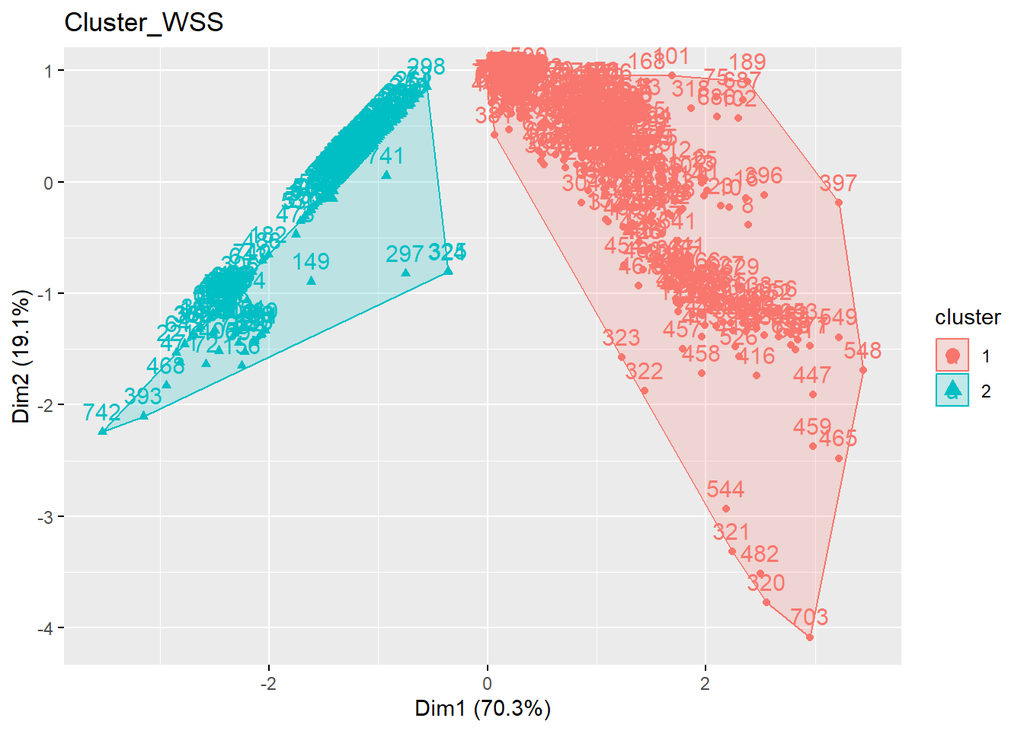

```r
fviz_cluster(kmeans_wis, data=fule_reciptss.norm, main="Cluster_WSS")
```

#The optimal value of k can be considered as k = 2 by using “WSS Method”.

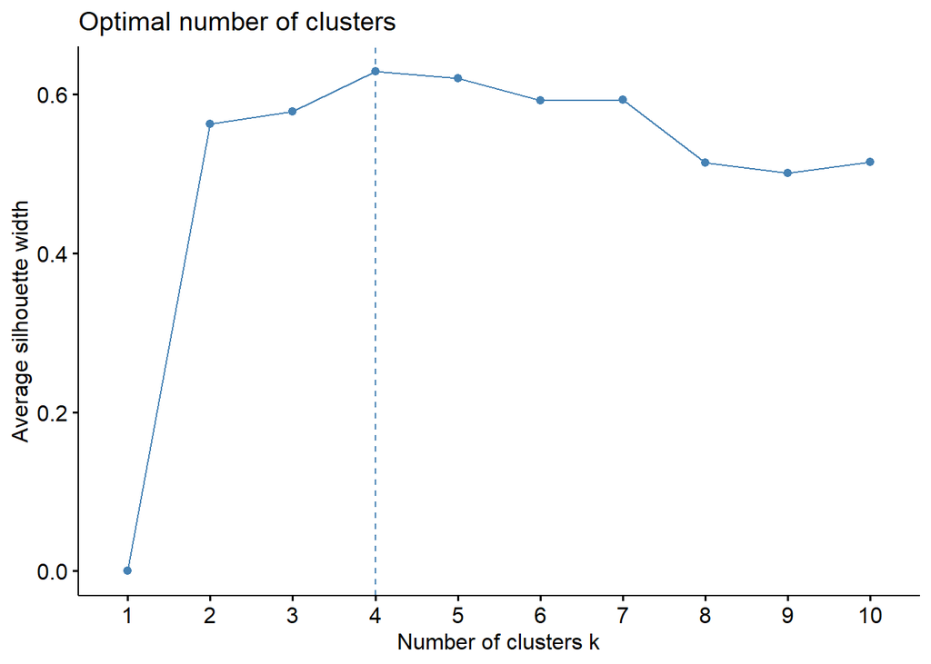

```r
fule_reciptss_silhouette <- fviz_nbclust(fule_reciptss.norm,kmeans,method="silhouette")
fule_reciptss_silhouette
```

#The accurate value of k can be considered as k = 4 by using “Silhouette Method”.

```r
kmeans_sil <- kmeans(fule_reciptss.norm,centers = 4)
kmeans_sil
```

```
## K-means clustering with 4 clusters of sizes 267, 90, 332, 67
##
## Cluster means:
##   sulfur_content_pct ash_content_pct fuel_cost_per_mmbtu
## 1        -0.68285701      -0.9756003           0.4267807
## 2         2.31460610       0.8087649          -0.7318205
## 3         0.03743433       0.7622339          -0.6717529
## 4        -0.57343169      -0.9756003           2.6109757
##
## Clustering vector:
##   [1] 3 3 1 3 3 3 1 2 3 3 3 3 3 4 1 3 3 3 3 3 3 1 3 3 3 3 3 3 3 3 3 3 3 3 3 3 3
##  [38] 3 3 1 1 3 3 3 3 3 3 2 3 3 2 3 3 3 2 4 4 4 4 4 3 3 1 1 3 3 3 3 3 3 3 4 1 1
##  [75] 3 1 1 1 1 4 1 1 1 1 1 1 1 1 1 1 1 1 1 1 1 3 3 3 3 1 3 3 3 1 1 1 1 1 1 1 3
## [112] 3 3 3 3 3 2 3 3 3 3 2 2 2 2 2 4 4 1 4 1 1 1 1 1 1 1 1 3 1 3 3 3 1 1 3 3 3
## [149] 4 1 1 3 3 4 1 4 1 1 1 1 1 1 1 1 1 3 3 3 1 3 3 3 3 1 1 3 3 3 3 1 3 4 3 3 1
```

[output cut: 25 more lines]

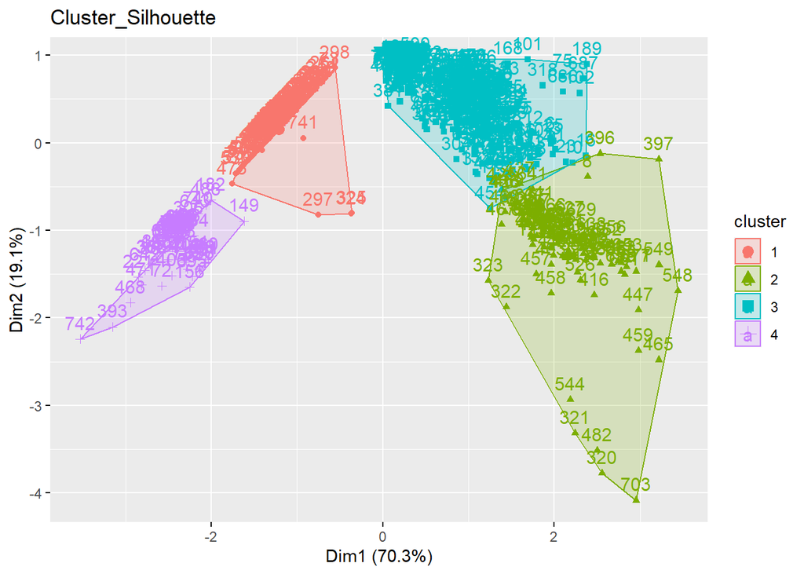

```r
fviz_cluster(kmeans_sil, data=fule_reciptss.norm, main="Cluster_Silhouette")
```

#To sum up, your clustering algorithm produced two clusters, and the degree of grouping tightness inside each cluster is indicated by the WCSS values. You can determine how well the clusters describe the overall variation in the data by looking at the percentage at the end.

#Because the results are expressed as standard deviations from the mean, they have been standardized, or normalized.The mean for each variable and each cluster denotes the average value of that variable inside that particular cluster.Negative numbers indicate that the mean is below the mean of the entire dataset, whilst positive values indicate that the mean is above it.

```r
clusters_wss <- kmeans_wis$cluster

clustering <- cbind(fule_reciptss,clusters_wss)
head(clustering)
```

|  | X | rowid | plant_id_eia | energy_source_code | fuel_type_code_pudl | fuel_group_code | supplier_name | fuel_received_units | fuel_mmbtu_per_unit | sulfur_content_pct | ash_content_pct | fuel_cost_per_mmbtu | clusters_wss |
| --- | --- | --- | --- | --- | --- | --- | --- | --- | --- | --- | --- | --- | --- |
| 1 | 1 | 1 | 3 | BIT | coal | coal | interocean coal | 259412 | 23.100 | 0.49 | 5.4 | 2.135 | 1 |
| 2 | 2 | 2 | 3 | BIT | coal | coal | interocean coal | 52241 | 22.800 | 0.48 | 5.7 | 2.115 | 1 |
| 3 | 3 | 3 | 3 | NG | gas | natural_gas | bay gas pipeline | 2783619 | 1.039 | 0.00 | 0.0 | 8.631 | 2 |
| 4 | 4 | 4 | 7 | BIT | coal | coal | alabama coal | 25397 | 24.610 | 1.69 | 14.7 | 2.776 | 1 |
| 5 | 5 | 5 | 7 | BIT | coal | coal | d & e mining | 764 | 24.446 | 0.84 | 15.5 | 3.381 | 1 |
| 6 | 6 | 6 | 7 | BIT | coal | coal | alabama coal | 603 | 24.577 | 1.54 | 14.6 | 2.199 | 1 |

```r
int_wis <- aggregate(clustering[,-c(1:7)],by=list(clustering$clusters),FUN="median")
print(int_wis[,-1])
```

```
##   fuel_received_units fuel_mmbtu_per_unit sulfur_content_pct ash_content_pct
## 1               20379              23.468               0.88               9
## 2                1884               1.025               0.00               0
##   fuel_cost_per_mmbtu clusters_wss
## 1              2.1290            1
## 2              8.6835            2
```

# just to check median of attributes in 2 clusters

```r
clusters_siltt <- kmeans_sil$cluster

clustering <- cbind(fule_reciptss,clusters_siltt)
head(clustering)
```

|  | X | rowid | plant_id_eia | energy_source_code | fuel_type_code_pudl | fuel_group_code | supplier_name | fuel_received_units | fuel_mmbtu_per_unit | sulfur_content_pct | ash_content_pct | fuel_cost_per_mmbtu | clusters_siltt |
| --- | --- | --- | --- | --- | --- | --- | --- | --- | --- | --- | --- | --- | --- |
| 1 | 1 | 1 | 3 | BIT | coal | coal | interocean coal | 259412 | 23.100 | 0.49 | 5.4 | 2.135 | 3 |
| 2 | 2 | 2 | 3 | BIT | coal | coal | interocean coal | 52241 | 22.800 | 0.48 | 5.7 | 2.115 | 3 |
| 3 | 3 | 3 | 3 | NG | gas | natural_gas | bay gas pipeline | 2783619 | 1.039 | 0.00 | 0.0 | 8.631 | 1 |
| 4 | 4 | 4 | 7 | BIT | coal | coal | alabama coal | 25397 | 24.610 | 1.69 | 14.7 | 2.776 | 3 |
| 5 | 5 | 5 | 7 | BIT | coal | coal | d & e mining | 764 | 24.446 | 0.84 | 15.5 | 3.381 | 3 |
| 6 | 6 | 6 | 7 | BIT | coal | coal | alabama coal | 603 | 24.577 | 1.54 | 14.6 | 2.199 | 3 |

```r
int_wis <- aggregate(clustering[,-c(1:7)],by=list(clustering$clusters),FUN="median")
print(int_wis[,-1])
```

```
##   fuel_received_units fuel_mmbtu_per_unit sulfur_content_pct ash_content_pct
## 1              3447.0              1.0220              0.000            0.00
## 2             19570.5             23.1215              3.015            8.75
## 3             20536.0             23.6720              0.700            9.25
## 4               703.0              5.8000              0.050            0.00
##   fuel_cost_per_mmbtu clusters_siltt
## 1              8.2680              1
## 2              1.6625              2
## 3              2.2020              3
## 4             19.2410              4
```

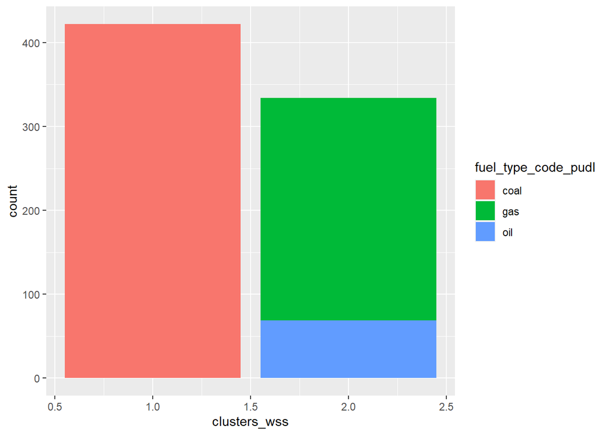

```r
ggplot(clustering,aes(x=clusters_wss,fill = fuel_type_code_pudl  )) + geom_bar()
```

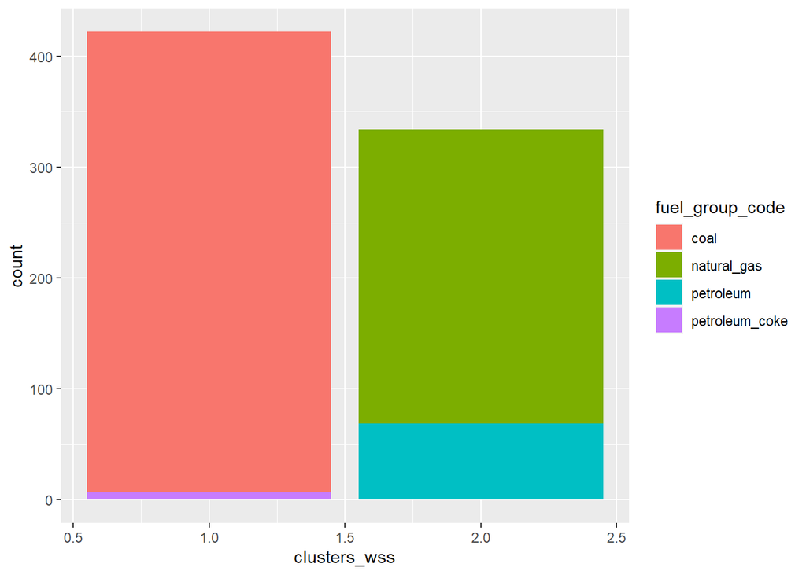

```r
ggplot(clustering,aes(x=clusters_wss,fill = fuel_group_code)) + geom_bar()
```

##DBSCAN

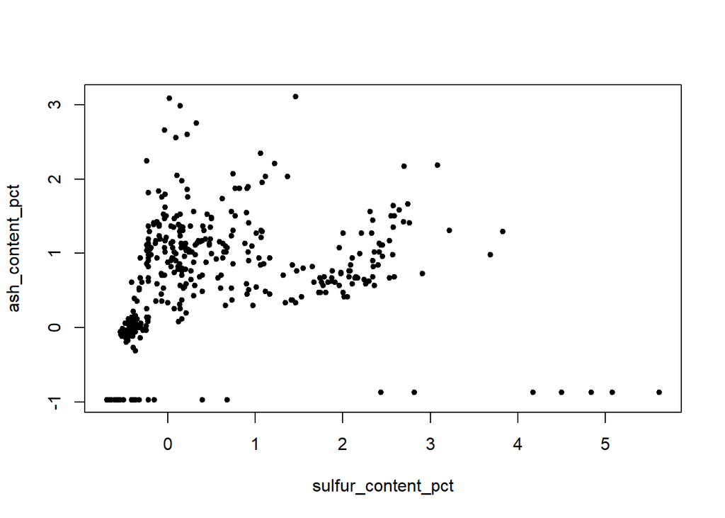

```r
plot(fule_reciptss.norm,pch=20)
```

# This data contains nonlinearity as well differing densities.

```r
DB <- fpc::dbscan(fule_reciptss.norm, eps=0.5, MinPts = 20)
print(DB)
```

```
## dbscan Pts=756 MinPts=20 eps=0.5
##         0   1   2  3
## border 31  38   2  5
## seed    0 360 262 58
## total  31 398 264 63
```

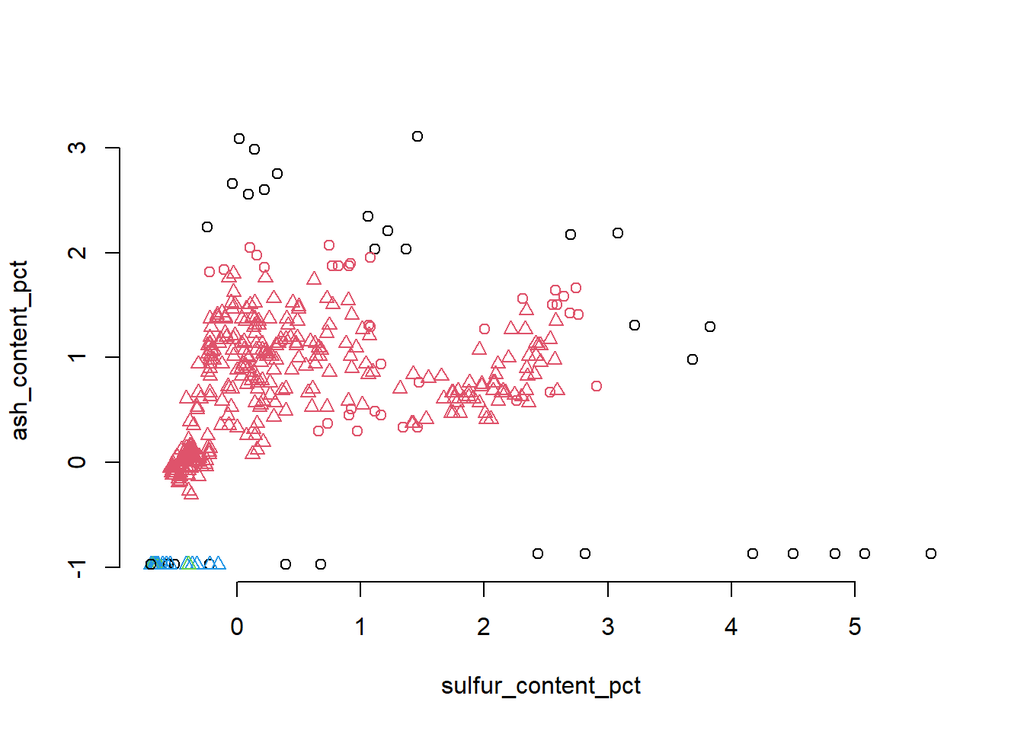

```r
plot(DB, fule_reciptss.norm, frame = FALSE)
```

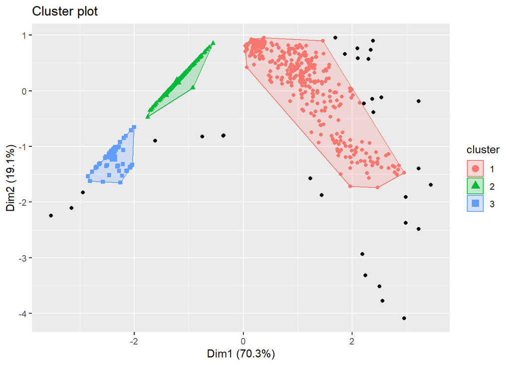

```r
fviz_cluster(DB, fule_reciptss.norm, stand = FALSE, frame = FALSE, geom = "point")
```

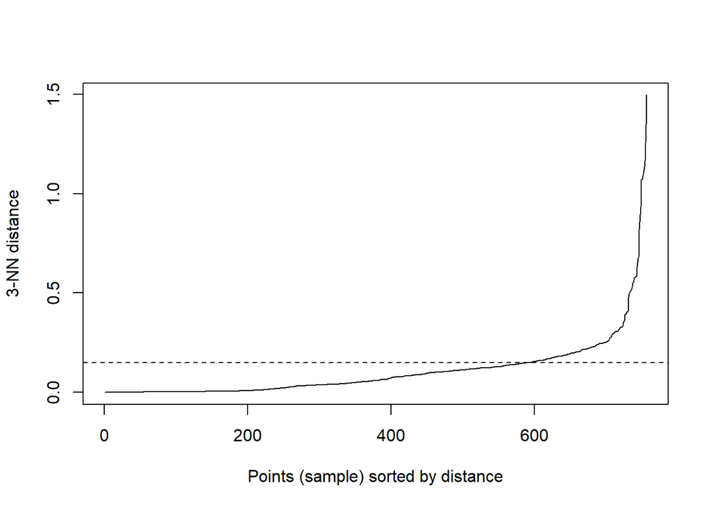

```r
dbscan::kNNdistplot(fule_reciptss.norm,k=3)
abline(h = 0.15, lty = 2)
```